# IODS course project

Sanni Moisio

# Introduction to Open Data Science - Course Project

# 1. About the project

I’m excited for this course since I think I already learned a bunch of new things at the installation/setup phase, although I use these key tools of the course, **R (studio) and GitHub**, already on a *daily basis*. Since I’m very much **self-learned**, it will be intriguing to learn new things about these tools and how to use them in a more sensible manner perhaps. Especially learning more about *the crosstalk between R (studio) and GitHub* will be very useful for me, while I’m also excited to dive into the other contents of the course.

To be honest, I didn’t go over the R for Health Data Science in detail *yet*, just merely browsed but I think it will be a great source of information regarding the later parts of the course. I’m quite familiar with R basics and plotting in R (often with ggplot2), but to be honest, I rarely use other tidyverse -related packages like dplyr anymore since I’m pretty much self-learned R user and usually I find other ways to execute things which I find to be more intuitive than the dplyr commands. But maybe I’ll be converted to a fan after the course, who knows!

**My GitHub page can be found at [my IODS-project GitHub page](https://github.com/sannimoisio/IODS-project).**

```r
# This is a so-called "R chunk" where you can write R code.

date()
```

```
## [1] "Fri Nov 17 12:22:57 2023"
```

# 2. Regression analysis

```r
date()
```

```
## [1] "Fri Nov 17 12:22:57 2023"
```

### Loading necessary R packages

```r
library(dplyr)
library(readr)
library(ggplot2)
library(GGally)
```

### 2.1 Learning 2014 dataset

```r
# reading in the learning 2014 dataset and saving it as a data frame in a variable called "data"
data <- as.data.frame(read_csv("/Users/sannimoi/Documents/courses/IODS/IODS-project/data/learning2014.csv", show_col_types = FALSE))

# checking the dimensions and structure of the data
dim(data)
```

```
## [1] 166   7
```

```r
# and structure of the data
str(data)
```

```
## 'data.frame':    166 obs. of  7 variables:
##  $ gender  : chr  "F" "M" "F" "M" ...
##  $ age     : num  53 55 49 53 49 38 50 37 37 42 ...
##  $ attitude: num  37 31 25 35 37 38 35 29 38 21 ...
##  $ deep    : num  3.58 2.92 3.5 3.5 3.67 ...
##  $ stra    : num  3.38 2.75 3.62 3.12 3.62 ...
##  $ surf    : num  2.58 3.17 2.25 2.25 2.83 ...
##  $ points  : num  25 12 24 10 22 21 21 31 24 26 ...
```

The original learning 2014 dataset was collected by Kimmo Vehkalahti in 2014-2015, which includes answers from 183 students to a variety of questions related to their learning and studying habits, as well as teaching on a course named Introduction to Social Statistics. The original dataset contained 60 variables and 183 observations (students), while the current dataset was processed using the original one and it includes 166 observations, and seven variables based on the dimensions and structure visible above. Checking the structure further reveals that the included variables are gender, age, attitude, deep, stra, surf, and points. While age and gender columns may be easy to understand, the rest of the variables may require a bit of clarification: attitude variable describes the global attitude towards statistics, deep variable is the average value from 12 questions related to deep learning, stra variable is the the average value from 8 questions related to strategic learning, surf variable is the the average value from 12 questions related to surface learning, and points refers to exam points. The deep, strategic and surface learning questions were all measured on the Likert scale (1-5, 1 = strongly disagree, 2 = disagree, 3 = neutral, 4 = agree, 5= strongly agree).

### 2.2 Graphical overview of the data

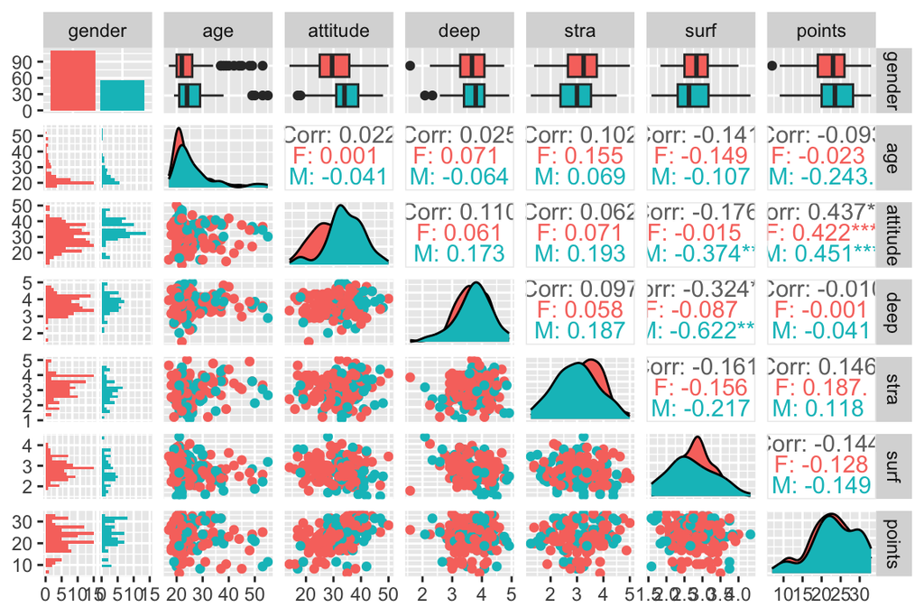

```r
# printing a graphical overview of the data, coloring the distributions by gender
ggpairs(data, mapping = aes(col=gender), lower = list(combo = wrap("facethist", bins = 20)))
```

In the graphical summary above, we can appreciate the distributions of each variable in the data and the relationships between the different variables. The data points, distributions and correlations are coloured by gender (red for female and blue for male students). The plots including gender look a bit different from the others, since it is the only variable in the data that is not numeric.

Overall, the number of female students who participated in the course is almost double compared to male counterparts, which needs to be kept in mind when interpreting the results. But overall, based on the distributions, the female students seem to be a bit younger on average, their global attitude to statistics scores lower, while they record slightly higher values for the strategic and surface learning questions compared to their male counterparts on average. In contrast, the deep learning and exam point distributions seem quite similar between the genders.

Regarding the correlations between the different variables, the results differ quite a bit depending on the gender. For instance, interestingly, the values from surface learning questions seemed to correlate negatively with both attitude and deep learning questions, but these correlations seem to be very specific to the male participants. Moreover, age seemed to have quite minimal correlations with any of the other variables, yet the points of male participants seemed to be negatively correlated with exam points. However, no conrete conclusions can be made due to the evident low number of male students of higher age. Most notably, attitude seems to have the highest positive correlation with exam points regardless of the gender.

### 2.3 Fitting regression models and interpreting the results

To explore further which variables seem to associate with the exam points variable, a regression model is fitted to the data with three explanatory variables. I chose attitude, stra and surf as the three explanatory variables since they seem to have the highest absolute correlation values with the exam points based on the summary plot above.

```r
# creating a regression model with multiple explanatory variables: for exam points attitude, stra and surf
my_model2 <- lm(points ~ attitude + stra + surf, data = data)
# printing out a summary of the model
summary(my_model2)
```

```
##
## Call:
## lm(formula = points ~ attitude + stra + surf, data = data)
##
## Residuals:
##      Min       1Q   Median       3Q      Max
## -17.1550  -3.4346   0.5156   3.6401  10.8952
##
## Coefficients:
##             Estimate Std. Error t value Pr(>|t|)
## (Intercept) 11.01711    3.68375   2.991  0.00322 **
## attitude     0.33952    0.05741   5.913 1.93e-08 ***
## stra         0.85313    0.54159   1.575  0.11716
## surf        -0.58607    0.80138  -0.731  0.46563
## ---
## Signif. codes:  0 '***' 0.001 '**' 0.01 '*' 0.05 '.' 0.1 ' ' 1
##
## Residual standard error: 5.296 on 162 degrees of freedom
## Multiple R-squared:  0.2074, Adjusted R-squared:  0.1927
## F-statistic: 14.13 on 3 and 162 DF,  p-value: 3.156e-08
```

The model is essentially describing how well the combination of attitude, stra and surf variables predict the outcome variable, exam points. In the printed summary above, we first have the description of residuals which essentially describe the difference between the actual observed values and the values estimated by the model, including the minimal and maximal differences, 1st and 3rd quantile values, and the median difference, which is about 0.5 in this case, so quite close to zero, which is good since the residuals seem to be quite symmetrical.

The coefficients table, in turn, describes the coefficients of the model which are basically two unknown constants of the linear model, intercept and slope. So essentially based on these calculated terms and the explanatory variables, we could estimate the outcome variable, i.e., exam points. The p-values are visible in the last column, and they essentially describe the results from a significance test testing the null hypothesis that either the intercept or the slope is 0. The first row in the coefficients table describes the intercept variable, essentially describing the estimated exam points if the values for the explanatory variables would be the average ones in the dataset. For the intercept, we reach a p-value of 0.00322 which is significant. In addition, in the table we have the standard error and t-value columns, which values are related since t value is the coefficient divided by standard error. Standard error essentially captures standard deviation, and we would like that to be as small as possible compared to the coefficient since it describes the level of uncertainty of the coefficient. In contrast, for a confident model, we would like to see a t-value as large as possible since a large t-value would indicate that the standard error is small in comparison to the coefficient. Here, the standard error seems to be relatively high, about 3.7 compared to our coefficient of about 11, and therefore the t-value also remains smaller than 3.

Since we have multiple explanatory variables, we have also a row for each of them describing the slope constant estimates based on each, as well as standard errors, t-values and p-values for each of these. We can see that the surf parameter (surface learning) is the only one with seemingly negative correlation with exam points (negative slope), and for it we have highest standard error as well as the smallest t-value, while accordingly the p-value for it is nearly 0.5, meaning that the any relationship between it and exam points has an almost 50% chance of arising just by chance. Therefore, I chose to fit the model again without the surf variable.

```r
# creating a regression model with multiple explanatory variables: for exam points attitude and stra
my_model2 <- lm(points ~ attitude + stra, data = data)

summary(my_model2)
```

```
##
## Call:
## lm(formula = points ~ attitude + stra, data = data)
##
## Residuals:
##      Min       1Q   Median       3Q      Max
## -17.6436  -3.3113   0.5575   3.7928  10.9295
##
## Coefficients:
##             Estimate Std. Error t value Pr(>|t|)
## (Intercept)  8.97290    2.39591   3.745  0.00025 ***
## attitude     0.34658    0.05652   6.132 6.31e-09 ***
## stra         0.91365    0.53447   1.709  0.08927 .
## ---
## Signif. codes:  0 '***' 0.001 '**' 0.01 '*' 0.05 '.' 0.1 ' ' 1
##
## Residual standard error: 5.289 on 163 degrees of freedom
## Multiple R-squared:  0.2048, Adjusted R-squared:  0.1951
## F-statistic: 20.99 on 2 and 163 DF,  p-value: 7.734e-09
```

```r
# creating a regression model with one explanatory variable, attitude, for exam points
my_model2 <- lm(points ~ attitude, data = data)
summary(my_model2)
```

```
##
## Call:
## lm(formula = points ~ attitude, data = data)
##
## Residuals:
##      Min       1Q   Median       3Q      Max
## -16.9763  -3.2119   0.4339   4.1534  10.6645
##
## Coefficients:
##             Estimate Std. Error t value Pr(>|t|)
## (Intercept) 11.63715    1.83035   6.358 1.95e-09 ***
## attitude     0.35255    0.05674   6.214 4.12e-09 ***
## ---
## Signif. codes:  0 '***' 0.001 '**' 0.01 '*' 0.05 '.' 0.1 ' ' 1
##
## Residual standard error: 5.32 on 164 degrees of freedom
## Multiple R-squared:  0.1906, Adjusted R-squared:  0.1856
## F-statistic: 38.61 on 1 and 164 DF,  p-value: 4.119e-09
```

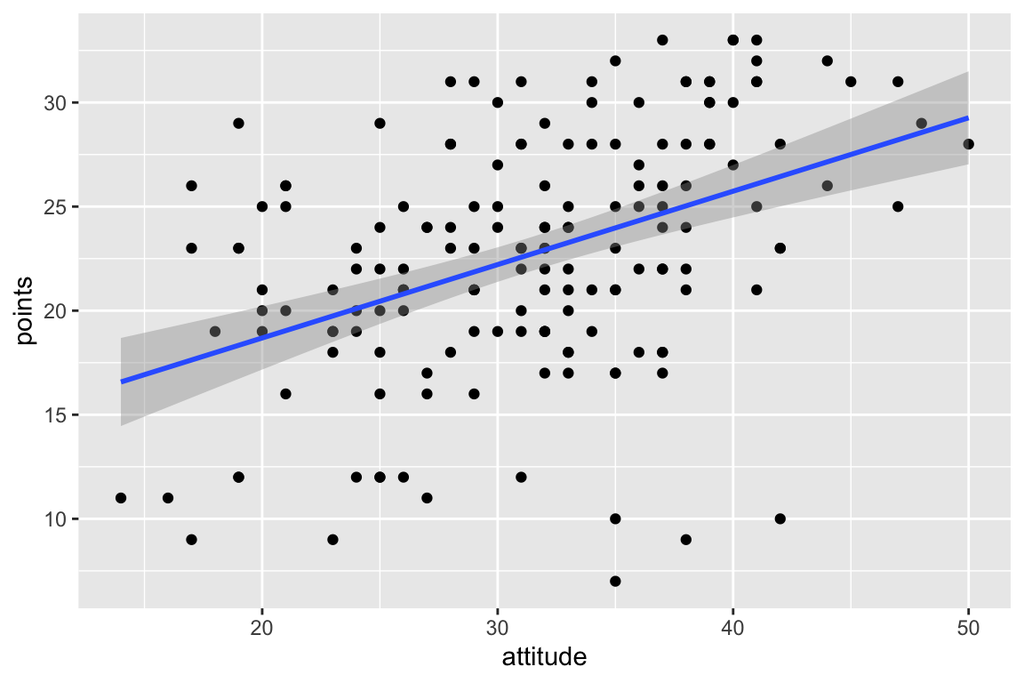

```r
qplot(attitude, points, data = data) + geom_smooth(method = "lm")
```

Now we can observe from the summary, that the model has further improved and reached a much more significant p-value for the intercept at 1.95e-09 and for the slope the p-value is almost as significant at 4.12e-09. Moreover, the standard error is now smaller and t-value has also improved as it is over 6 for both intercept and slope.

The R-squared statistic in the model describes how well the model fits the actual observed data, essentially depicting the proportion of variance and measuring the linear relationship between the predictor variable, attitude, and target variable, exam points. Basically in the present model, roughly 19% of the variance of the exam points variable can be explained by the attitude score.

### 2.4 Diagnostic plots

The linear regression model includes some assumptions about the data, so next we will plot a few diagnostics plots to interpret if those assumptions apply to the present dataset.

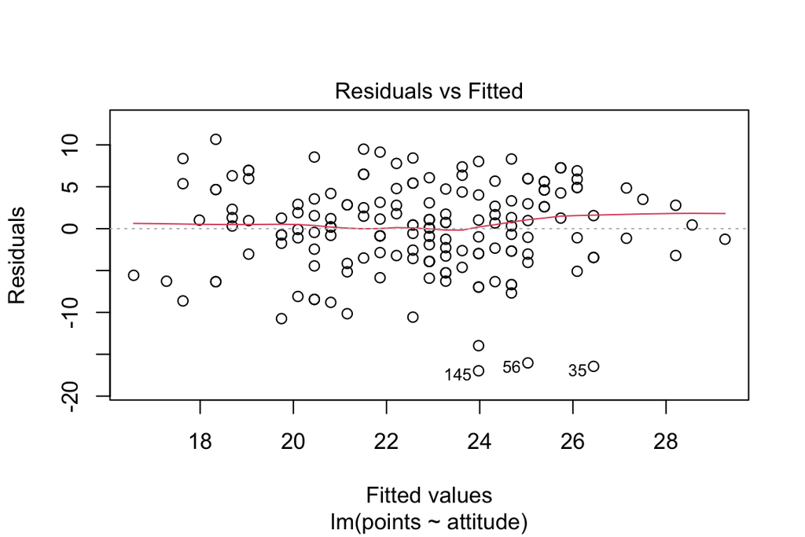

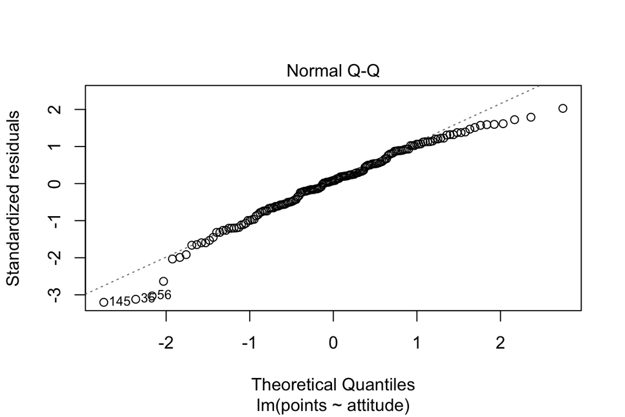

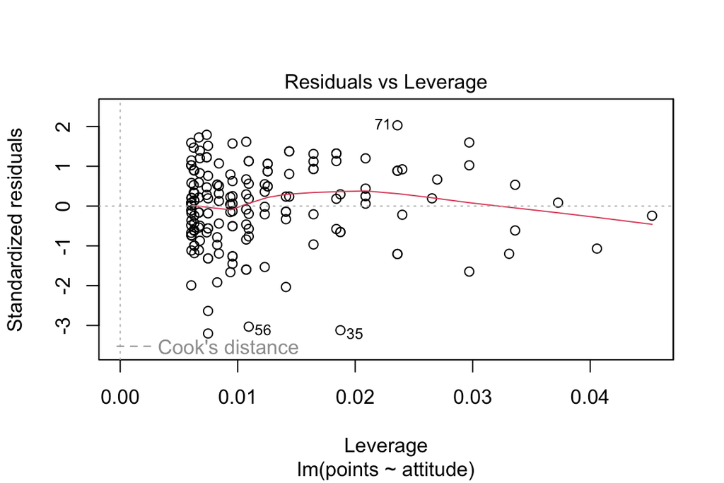

```r
# generating selected diagnostic plots: Residuals vs Fitted values, Normal QQ-plot and Residuals vs Leverage
plot(my_model2, which=c(1,2,5))
```

The linear model assumes a linear relationship between the explanatory and outcome variables, and this assumption can be checked from the residuals vs fitted plot. There seems to be a linear horizontal line without distinct patterns, so indeed the assumption of a linear relationship seems to apply here.

Secondly, the residual errors are assumed to be normally distributed, which assumption can be evaluated based on the normal Q-Q plot. The residuals points should follow the straight dashed line, which seems to apply here relatively well at least for majority of values. However, some discrepancy can be seen for very small and high values, which is quite normal, though.

Furthermore, the model assumes that residuals have a constant variance, and hence we would like to check that there are no cases in the dataset that have extreme values that might highly affect the regression results if excluded/included. This can be evaluated based on the residuals vs leverage plot, in which the 3 most extreme points are highlighted. We have a few cases which seem to exceed 3 standard deviations which represent potential outliers, and it might be useful to test the model fit without these.

Based on these observations, it can be concluded that the model assumptions apply relatively well to the present dataset.

### 2.5 Summary

In summary, we can confidently say that there seems to be a relationship between the attitude and exam variables since we get a very significant p-value for the model. However, the p-value should not to be interpreted in such a way that the estimation of exam points would be highly confident if we know the attitude score, since we have to acknowledge that only less than 20% of the variability of the exam points variable is explained by the attitude.

# 3. Logistic regression

```r
date()
```

```
## [1] "Fri Nov 17 12:23:04 2023"
```

### Loading necessary R packages

```r
library(boot)
library(readr)
library(dplyr)
library(tidyr)
library(ggplot2)
```

### 3.1 Alcocol consumption dataset

Reading in the joined student alcohol consumption dataset.

```r
# reading in the dataset
alc <- read.csv("/Users/sannimoi/Documents/courses/IODS/IODS-project/data/alc.csv")
# checking the names of the variables, i.e., columns
colnames(alc)
```

```
##  [1] "school"     "sex"        "age"        "address"    "famsize"
##  [6] "Pstatus"    "Medu"       "Fedu"       "Mjob"       "Fjob"
## [11] "reason"     "guardian"   "traveltime" "studytime"  "schoolsup"
## [16] "famsup"     "activities" "nursery"    "higher"     "internet"
## [21] "romantic"   "famrel"     "freetime"   "goout"      "Dalc"
## [26] "Walc"       "health"     "failures"   "paid"       "absences"
## [31] "G1"         "G2"         "G3"         "alc_use"    "high_use"
```

The current dataset was retreived from http://www.archive.ics.uci.edu/dataset/320/student+performance and it contains information about performance of Portuguese secondary education students in two subjects, math and Portuguese. For the present purpose, we have combined the two datasets, and read that modified data in. There are several variables that can be easily understood based on the column name, like school, sex, age, address etc. But especially Dalc and Walc variables are important here, since they describe alcohol consumption on the workdays and weekends, respectively, while alc_use is the mean value of the two and high_use column is set to TRUE if alc_use exceeds 2.

### 3.2 Hypotheses

The purpose of this analysis is to study the relationships between high/low alcohol consumption and some other variables in the data. I have chosen the following variables to study:

- failures - number of past class failures (numeric: n if 1<=n<3, else 4)
- studytime - weekly study time (numeric: 1 - <2 hours, 2 - 2 to 5 hours, 3 - 5 to 10 hours, or 4 - >10 hours)
- famrel - quality of family relationships (numeric: from 1 - very bad to 5 - excellent)
- absences - number of school absences (numeric: from 0 to 93)

I hypothesize that weekly study time and and quality of family relationships would negatively correlate with alcohol consumption, i.e., that a higher value for these factors would usually associate with lower alcohol consumption. Regarding the number of school absences and past class failures, I assume the opposite, i.e., that there would be a positive correlation between higher alcohol consumption and higher number of absences/failures.

### 3.3 Variable distributions and relationships

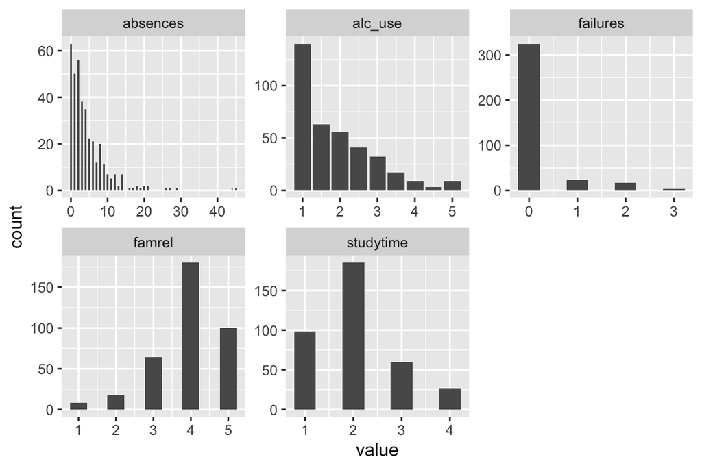

```r
# drawing a bar plot of each chosen variable
gather(alc[,c("failures", "studytime", "famrel", "absences", "alc_use")]) %>% ggplot(aes(value)) + facet_wrap("key", scales = "free") + geom_bar()
```

```r
# and then summarizing the number of students that have been classified to the high alcohol usage group
alc %>% group_by(high_use) %>% summarise(count = n())
```

```
## # A tibble: 2 × 2
##   high_use count
##   <lgl>    <int>
## 1 FALSE      259
## 2 TRUE       111
```

In general, based on the plots and table above, we can observe that most students have a reasonable number of absences, only a few standing out with more than 15, and also that vast majority of students haven’t failed any classes in the past. Majority of students also fall into the category of low alcohol consumption (high use = FALSE & less than 2 portions based on the barplot) yet still about 30% have been classified into the high alcohol use group. Most students also report good/excellent quality family relationships, while study time per week, in turn, seems to average around 2-5 hours per week, as category 2 stands out as the most common one there, studying less than that being the reality for about 100 students, while less than 100 report studying more than 5 hours.

```r
# creating cross-tabulations describing the numbers in each candidate explanatory variable category and the high/low alcohol usage category
table(high_use = alc$high_use, prediction = alc$failures)
```

```
##         prediction
## high_use   0   1   2   3
##    FALSE 238  12   8   1
##    TRUE   87  12   9   3
```

```r
table(high_use = alc$high_use, prediction = alc$studytime)
```

```
##         prediction
## high_use   1   2   3   4
##    FALSE  56 128  52  23
##    TRUE   42  57   8   4
```

```r
table(high_use = alc$high_use, prediction = alc$famrel)
```

```
##         prediction
## high_use   1   2   3   4   5
##    FALSE   6   9  39 128  77
##    TRUE    2   9  25  52  23
```

```r
table(high_use = alc$high_use, prediction = alc$absences)
```

```
##         prediction
## high_use  0  1  2  3  4  5  6  7  8  9 10 11 12 13 14 16 17 18 19 20 21 26 27
##    FALSE 50 37 40 31 24 16 16  9 14  5  5  2  3  1  1  0  0  1  0  2  1  0  0
##    TRUE  13 13 16  7 11  6  5  3  6  6  2  3  4  1  6  1  1  1  1  0  1  1  1
##         prediction
## high_use 29 44 45
##    FALSE  0  0  1
##    TRUE   1  1  0
```

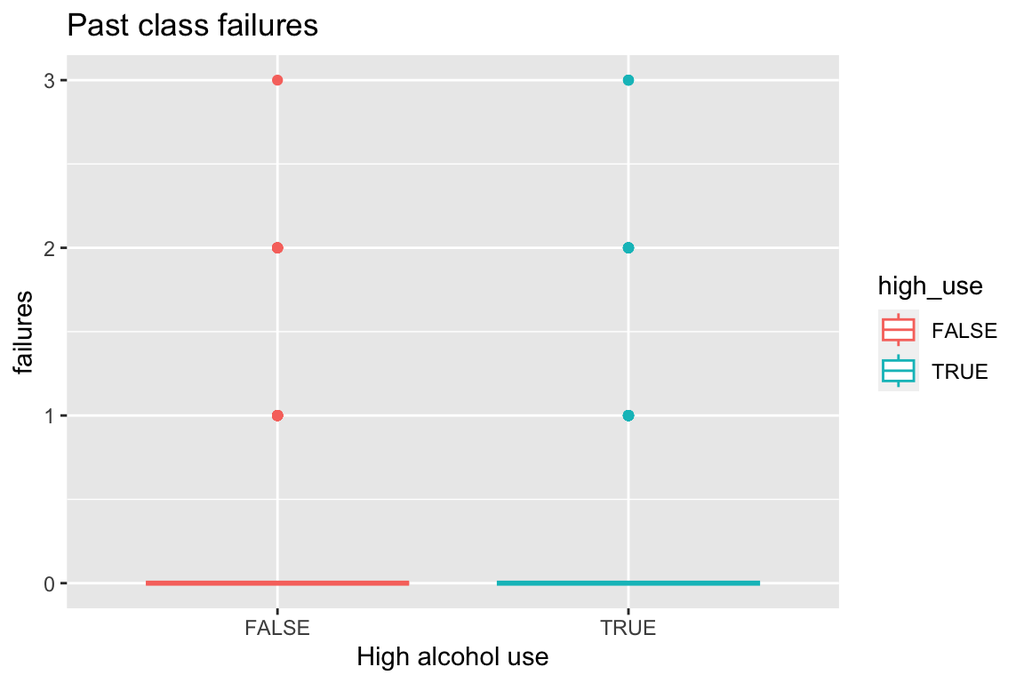

```r
# plotting boxplots to study the relationship between the alcohol usage (high or not) and the chosen variables

# drawing boxplots comparing values between the high vs low alcohol usage groups
ggplot(alc, aes(x = high_use, y = failures, col=high_use)) + geom_boxplot() + ggtitle("Past class failures") + xlab("High alcohol use")
```

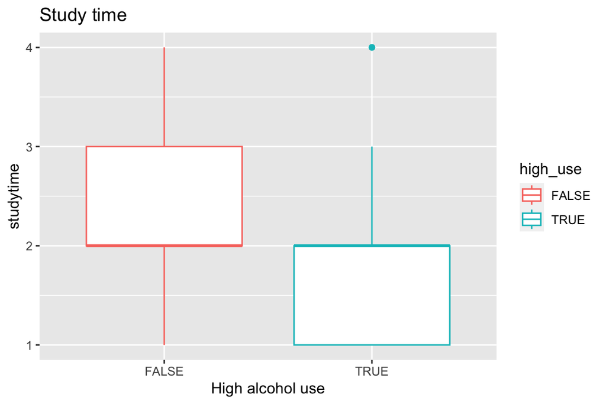

```r
ggplot(alc, aes(x = high_use, y = studytime, col=high_use)) + geom_boxplot() + ggtitle("Study time") + xlab("High alcohol use")
```

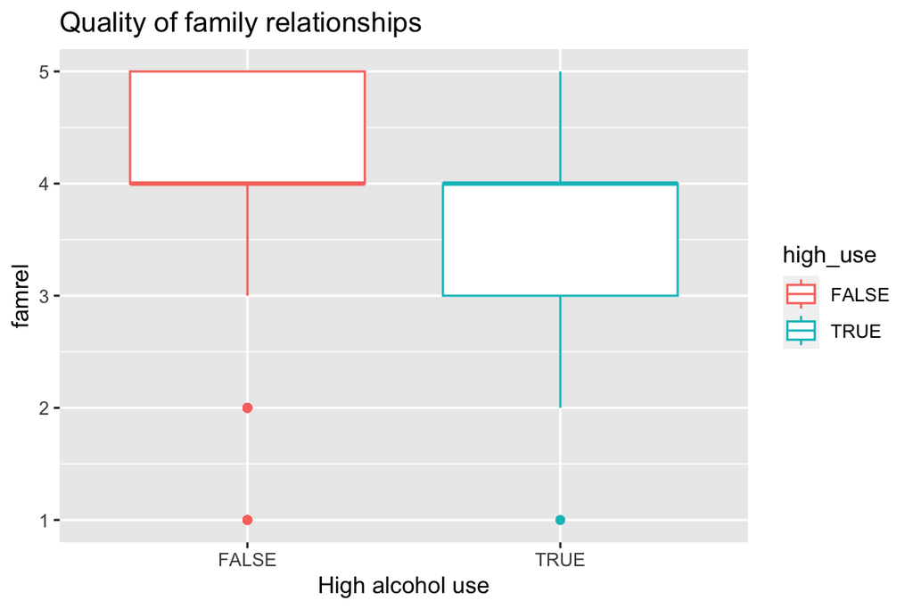

```r
ggplot(alc, aes(x = high_use, y = famrel, col=high_use)) + geom_boxplot() + ggtitle("Quality of family relationships") + xlab("High alcohol use")
```

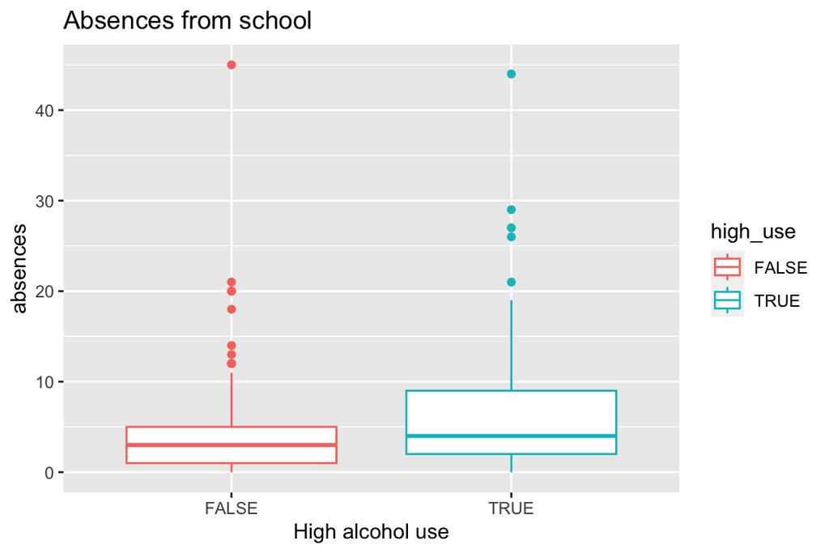

```r
ggplot(alc, aes(x = high_use, y = absences, col=high_use)) + geom_boxplot() + ggtitle("Absences from school") + xlab("High alcohol use")
```

From the tables and plots above, we can get some idea whether the chosen variables seem to have any relationship with the high alcohol consumption. As I assumed, the students reporting high alcohol consumption study less on average based on study time and report family relationships of lower quality on average. Also, as I hypothesized, the number of absences from school seemed to be higher on average in the group with high alcohol use. The relationship of failed classes, however, is difficult to evaluate based on the boxplot, since so few students had previously failed classes, yet some indication of a correlation can be observed from the table, as more students that have 2 or more failed classes also consume high amount of alcohol.

### 3.4 Logistic regression

To statistically explore the relationship between the chosen explanatory variables and the high/low alcohol consumption target variable, a logistic regression model will be fitted.

```r
# fitting the model, using failres, studytime, famrel and absences as the explanatory variables
model <- glm(high_use ~ failures + studytime + famrel + absences, data = alc, family = "binomial")
# printing the summary
summary(model)
```

```
##
## Call:
## glm(formula = high_use ~ failures + studytime + famrel + absences,
##     family = "binomial", data = alc)
##
## Deviance Residuals:
##     Min       1Q   Median       3Q      Max
## -2.0531  -0.7954  -0.6253   1.0826   2.1737
##
## Coefficients:
##             Estimate Std. Error z value Pr(>|z|)
## (Intercept)  0.60734    0.61872   0.982 0.326292
## failures     0.49010    0.20416   2.401 0.016370 *
## studytime   -0.48901    0.15962  -3.064 0.002187 **
## famrel      -0.24724    0.12916  -1.914 0.055598 .
## absences     0.07417    0.02246   3.303 0.000958 ***
## ---
## Signif. codes:  0 '***' 0.001 '**' 0.01 '*' 0.05 '.' 0.1 ' ' 1
##
## (Dispersion parameter for binomial family taken to be 1)
##
##     Null deviance: 452.04  on 369  degrees of freedom
## Residual deviance: 409.94  on 365  degrees of freedom
## AIC: 419.94
##
## Number of Fisher Scoring iterations: 4
```

```r
# then printing the odds ratios of the coefficients
exp(coef(model))
```

```
## (Intercept)    failures   studytime      famrel    absences
##   1.8355483   1.6324760   0.6132323   0.7809515   1.0769908
```

```r
# and then printing the confidence intervals for the coefficients
confint(model)
```

```
##                   2.5 %       97.5 %
## (Intercept) -0.60724157  1.826969798
## failures     0.09542278  0.902367559
## studytime   -0.81145054 -0.184130907
## famrel      -0.50161742  0.006600938
## absences     0.03228991  0.120768107
```

Looking at the summary of the logistic regression model, we can interpret the residuals similarly to linear regression, as they essentially describe the difference between the actual observed values and the values estimated by the model, including the minimal and maximal differences, 1st and 3rd quantile values, and the median difference, which is about -0.6253 in this case. Moreover, the coefficients table describes the estimated intercept term and the slope terms for each explanatory variables, while p-values for each are also given. The p-value for the intercept remains quite high at 0.33, while p-values for all the slope terms except famrel are significant. The null deviance describes the value when only taking intercept term into account, while residual deviance is the value when all variables are taken into account, so the higher the difference, better the model. The difference doesn’t seem very notable in this case. The AIC, in turn, would be useful in comparing the fit of multiple regression models, as it could help to find the model that explains the most variation in the data, the lower the AIC the better.

The confidence intervals, in turn, describe the range of estimated values for a parameter, and basically here we can state that we can be 95% confident that the slope for each explanatory variable is between the intervals visible above. E.g., it is likely that the slope for failures id between 0.095 and 0.902, which seems to be quite a wide scale, also visible in the p-value for the slope (0.016370), which is higher compared to e.g. absences, although the odds ratio for absences is not so high as for failures. For absences, in turn, the confidence interval is between 0.032 and 0.121, and the p-value is highly significant at 0.000958, which highlights that to explore the relationship between an explanatory and outcome variable, one should check both the odds ratio and the confidence estimates of the relationship between the two variables, like the p-value and confidence intervals.

Since famrel variable, did not have a significant relationship to alcohol consumption, removing that from the model and testing the predictive power of the improved model next.

### 3.5 Exploring the predictive power of the logistic regression model

```r
# since quality of family relationships did not seem to have that significant relationship with alcohol consumption, fitting the model without it
model2 <- glm(high_use ~ failures + studytime + absences, data = alc, family = "binomial")

# predicting the probability of high_use based on the model
probabilities <- predict(model2, type = "response")

# adding the predicted probabilities to alc
alc <- mutate(alc, probability = probabilities)

# using the probabilities to make a prediction of high_use
# classifying probability > 0.5 as a cutoff for high use
alc <- mutate(alc, prediction = probability > 0.5)

# generating a 2x2 cross tabulation
table(high_use = alc$high_use, prediction = alc$prediction)
```

```
##         prediction
## high_use FALSE TRUE
##    FALSE   246   13
##    TRUE     86   25
```

```r
# calculating for how many students the prediction is wrong
n_wrong <- 0
for (i in 1:nrow(alc)) {
  if (alc$high_use[i]!=alc$prediction[i]) {n_wrong <- (n_wrong+1)}}
n_wrong
```

```
## [1] 99
```

```r
# since there are 370 students in total, the training error can be calculated n_wrong/370
n_wrong/370
```

```
## [1] 0.2675676
```

```r
# then checking how well would random predictions work
# doing the following steps 100 times to derive an estimate of how well a random classification performs compared to our model
random_errors <- vector()
for (j in 1:100) {
  # sampling the high use column to derive a new randomized column with the same ratio of TRUE/FALSE  values
  alc["high_use_random"] <- sample(alc$high_use)
  # then calculating how many wrong predictions we get from this random classification
  n_wrong <- 0
  for (i in 1:nrow(alc)) {
    if (alc$high_use[i]!=alc$high_use_random[i]) {n_wrong <- (n_wrong+1)}}
  # since there are 370 students in total, the training error can be calculated n_wrong/370
  random_errors <- append(random_errors, n_wrong/370)
}
# then checking the mean, median and range of the error rate of these randomized classifications
mean(random_errors)
```

```
## [1] 0.4234595
```

```r
median(random_errors)
```

```
## [1] 0.4216216
```

```r
range(random_errors)
```

```
## [1] 0.3729730 0.4756757
```

Based on the model, we can say pretty confidently that the chosen variables in the final model, weekly study time, number of past class failures and school absences, seem to have a relationship with the outcome variable, alcohol consumption. However, the predictive power of the model, i.e., predicting alcohol consumption based on the variables, is by no means ideal, since the classification to high/low consumption group fails almost 27% percent of the time (= training error), which is still somewhat better than what you would get by grouping the students by random (on average 42% error rate from 100 randomizations) yet far from something we would call a confident predictive model.

(more chapters to be added similarly as we proceed with the course!)